# Day 2 Part 2 Lab Key

Christopher Loan

February 21, 2023

# Run this Code to Get Set up

```r
set.seed(022023)
library(tidyverse)
library(rsample)
library(rpart.plot)
library(ranger)
library(vip)

key <-
  read.csv(here::here('data/keys', 'key_impute.csv'))

dat <-
  read.csv(
    here::here(
      'data',
      'se_asia_imputed_world_bank.csv'
    )
  )

sea_split <- initial_split(dat, strata = country_name, prop = 0.9)
sea_training <- training(sea_split)
sea_testing <- testing(sea_split)
```

# Begin Lab: Fitting Models

Using all variables in the data, predict `bx_gsr_totl_cd`.

`bx_gsr_totl_cd` = Exports of goods, services and primary income (BoP, current US$)

Because this data set has a large number of variables, do this with `formula = bx_gsr_totl_cd ~ .` instead of manually typing all predictors.

Leave all hyperparameters at their default values

## Decision Tree

Store the object as `all_vars_DT`.

```r
all_vars_DT <-
  rpart(
    bx_gsr_totl_cd ~ .,
    data = sea_training
    )
```

## Random Forest

Store the object as `all_vars_RF`.

```r
all_vars_RF <-
  ranger(
    bx_gsr_totl_cd ~ .,
    data = sea_training
    )
```

# Assessing Default Models (DT & RF)

## Predict Outcome for `sea_testing` with DT

Use `predict()` with the `all_var_DT` and `sea_testing` to get predict the outcome (`bx_gsr_totl_cd`) on unseen data.

Store this as a vector called `DT_preds`.

**HINT** if you need the help documentation, use `?rpart:::predict.rpart` instead of `?predict`

```r
DT_preds <-
  predict(all_vars_DT, newdata = sea_testing)
```

## Predict Outcome for `sea_testing` with RF

Use `predict()` with the `all_var_RF` and `sea_testing` to get predictions on unseen data.

Store this as a vector called `RF_preds`.

**HINT** if you need the help documentation, use `?ranger:::predict.ranger()` instead of `?predict`. The argument to input unseen data differs from DTs and RFs.

```r
RF_preds <- predict(all_vars_RF, data = sea_testing)$predictions
```

# Assess Fit

## Make Prediction Data Frame

Store the object as `predictions_df`.

```r
predictions_df <-
  tibble(
    preds_DT = DT_preds,
    preds_RF = RF_preds,
  )
```

Add a column to `predictions_df` which has the actual values (i.e., `sea_testing$bx_gsr_totl_cd`) name the column `actual`.

```r
predictions_df$actual <- sea_testing$bx_gsr_totl_cd
```

## Calculate Mean Squared Error (MSE) by Model

Here’s a function to calculate MSE from 2 vectors

```r
mse <- function(observed_y, predicted_y){
  mean((observed_y - predicted_y)^2)
}
```

Below, I provide code to do this for the DT.

Store your final result as `default_DT_mse`

```r
default_DT_mse <-
  mse(
    observed_y = sea_testing$bx_gsr_totl_cd,
    predicted_y = DT_preds
  )
default_DT_mse
```

```
## [1] 1.737757e+21
```

Repeat this for the RF; store your final result as `default_RF_mse`

```r
default_RF_mse <-
  mse(
    observed_y = predictions_df$actual,
    predicted_y = RF_preds
  )
```

# QUESTION

Which model predicts `bx_gsr_totl_cd` better (i.e., with lower MSE)?

# Manual Tuning

For this example, we’ll see the impact of varying one hyperparameter (per model) on model fit, measured by mean squared error (MSE).

I provide example code for a decision tree, which you can modify for the random forest.

**HINT** remember, lower MSE indicates a better model

## DT

I am going to assess the impact of varying `minbucket` on the accuracy of the DT.

`minbucket` = `the minimum number of observations in any terminal <leaf> node`

The default is 7

see `?rpart.control` for more details.

### Make a vector of possible `minbucket` values

```r
minbucket_vector <- seq(1, round(0.3*nrow(sea_training)), 1)
```

### Loop through `minbucket` values.

```r
DT_temp <- list()
DT_mses <- vector()
for (i in 1:length(minbucket_vector)){

  # Fit DT

  DT_temp[[i]] <-
    rpart(
      data = sea_training,
      formula = bx_gsr_totl_cd ~ .,
      minbucket = minbucket_vector[[i]]
    )

  # Get Predictions

  temp_DT_predictions <-
    predict(DT_temp[[i]], newdata = sea_testing)

  # store MSEs
  DT_mses[i] <-
    mse(
      observed_y = sea_testing$bx_gsr_totl_cd,
      predicted_y = temp_DT_predictions
    )

}
```

### Store Results

Create a data frame with `DT_mses` and their corresponding `minbucket` values.

```r
## create a table
DT_mse_df <-
  tibble(
    DT_mses = DT_mses,
    minbucket_vector = minbucket_vector
  )
```

### Plot Results

Using the prior data frame, plot `DT_mses` on the `y-axis` and `minbucket` on the x-axis

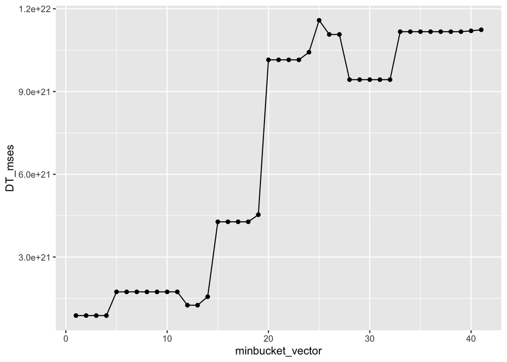

```r
minimum_MSE_DT <- which.min(DT_mse_df$DT_mses)
best_minbucket <-  DT_mse_df$minbucket_vector[minimum_MSE_DT]

ggplot(
  data = DT_mse_df,
    aes(
      x = minbucket_vector,
      y = DT_mses
      )
  ) +
  geom_point() +
  geom_line()
```

## RF

### Make a vector of possible `mtry` values

run this code to make several possible `mtry` values

```r
mtry_vector <- seq(1, ncol(sea_testing)-1, 1)
```

```r
RF_temp <- list()
RF_mses <- vector()
for (i in 1:length(mtry_vector)){

  # Fit RF

  ### REPLACE THIS WITH CODE TO FIT RANDOM FOREST

  RF_temp[[i]] <-
    ranger(
      data = sea_training,
      formula = bx_gsr_totl_cd ~ .,
      mtry = mtry_vector[[i]]
    )

  # Get Predictions
  temp_RF_predictions <-
    predict(RF_temp[[i]], data = sea_testing)$predictions

  # Store MSEs

  RF_mses[i] <-
    mse(
      observed_y = sea_testing$bx_gsr_totl_cd,
      predicted_y = temp_RF_predictions
    )

}
```

### Store Results

Create a data frame with `RF_mses` and their corresponding `mtry` values.

```r
## create a table
RF_mse_df <-
  tibble(
    RF_mses = RF_mses,
    mtry_vector = mtry_vector
  )
```

### Plot Results

Using the prior data frame, plot `RF_mses` on the `y-axis` and `mtry` on the x-axis

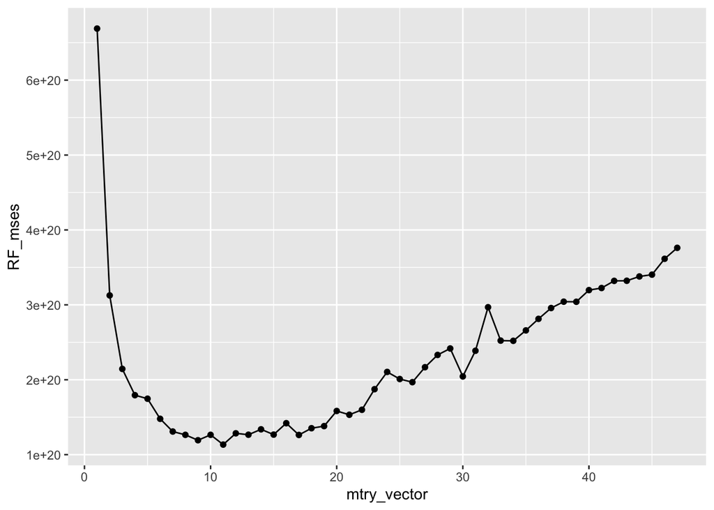

```r
minimum_MSE <- which.min(RF_mse_df$RF_mses)
best_mtry <-  RF_mse_df$mtry_vector[minimum_MSE]

ggplot(
  data = RF_mse_df,
    aes(
      x = mtry_vector,
      y = RF_mses
      )
  ) +
  geom_point() +
  geom_line()
```

# Questions

- what is the optimal value of `minbucket` for the DT and the corresponding MSE?
- what is the optimal value of `mtry` for the RF and the corresponding MSE??
- what is the lowest MSE we observed today?

# Finished Early?

If you finish early, try this again and try to find an even lower MSE.

You could do this with:

- tuning a different hyperparameter
- tuning a wider range of hyperparameters
- tuning multiple hyperparameters.